# BRMS analysis | Posnalpha Behave | target window | zscored by subject x cue_validity

Christopher Gundlach

2024-08-14

# Get everything up and running

## Initialize environment

**Setting up R libraries**

## load single trial data

Loading data C:/Users/EEG/Documents/R/Christopher/ssvep_posnalpha_behave_R/data_in/Behavior_FFT_singletrials_target.txt

The data has the following structure

- trialnumber = trial
- blocknumber
- trial_timing_type = 1=regular; 2=control
- cue_validity = 1=valid, 2=invalid, 3=neutral
- cue_validity_label
- cue_direction = 1=left, 2=right
- cue_direction_label
- cue_onset_fr = frame number of cue presentation
- cue_onset_t_est = onset time in ms
- cue_onset_t_meas = nan
- pre_event_type = 1=shorter, 2=longer, NaN=no event
- pre_event_onset_fr = onset frame of event
- pre_event_onset_t_est = onset time in ms
- pre_event_onset_t_meas = nan
- post_event_pos = position of post event: 1 = left, 2=right
- post_event_pos_label
- post_event_direction = direction of target (-90:90)=top;
- post_event_direction_c = category of target position: 1=top; 2=bottom
- post_event_direction_c_l = label
- post_event_dimenstion = size in degrees
- post_event_onset_fr = onset frames of event
- post_event_onset_t_est = onset times of events
- post_event_onset_t_meas = nan
- triggernum = trigger number
- pre_hit = empty=no event, TRUE=hit, 0=error, NaN=miss
- pre_RT = RT in ms
- post_hit = TRUE=hit, 0=error, NaN=miss
- post_RT = RT in ms
- subject
- FFT measures …

## wrangle data

from *long* formant to *longer* format

# Analysis Pipeline with brms package

## Implementing the workflow

### Fitting the models

*basic models*

- intercept model: **RT ~ 1 + ( 1 | subjects)**
- validity model: **RT ~ Cue + ( cue | subjects)**

*visual alpha models*

- contra target + contra nontarget + validity: **RT ~ Cue x visual_alpha_Targ + Cue x visual_alpha_NonTarg + ( cue | subjects)**

*ssvep models*

- target ssvep + validity: **RT ~ Cue x SSVEP + ( cue | subjects)**

*motor alpha models*

- contra target motor alpha + validity: **RT ~ Cue x motor_alpha + ( cue | subjects)**

```r
modeldata = DATA.In_long %>%
  filter(post_hit == "hit")

# intercept model
fit_intercept = brm(formula = post_RT ~ 1 + (1|subject),
          data = modeldata,
          family = shifted_lognormal(),
          file = 'fit_targ_intercept_slog',
          save_pars = save_pars(all = TRUE),
          # file_refit = "on_change",
          # file_refit = "always",
          file_refit = "never",
          cores = 4
          )  # Save all that hard work.


# validity model
fit_validity = brm(formula = post_RT ~ cue_validity_label + (cue_validity_label|subject),
          data = modeldata,
          family = shifted_lognormal(),
          file = 'fit_targ_validity_slog',
          save_pars = save_pars(all = TRUE),
          # file_refit = "on_change",
          # file_refit = "always",
          file_refit = "never",
          cores = 4
          )  # Save all that hard work.



# alter data to extract post-cue alpha contra to target
modeldata2 = DATA.In_longer %>%
  filter(post_hit == "hit", signal == "visualAlpha", time == "[-1000 0]ms", pos_rel_target == "contra_target")%>%
  mutate(post_cue_vis_alpha_contra_target = amplitude)



# combined alpha model
# alter data to extract post-cue alpha contra to target
modeldata4 = DATA.In_longer %>%
  filter(post_hit == "hit", signal == "visualAlpha", time == "[-1000 0]ms")%>%
  dplyr::select(subject, trialnumber, cue_validity_label, post_RT, pos_rel_target, amplitude) %>%
  pivot_wider(names_from = "pos_rel_target", values_from = amplitude) %>%
  group_by(subject,cue_validity_label)%>%
  mutate("contra_nontarget"=scale(contra_nontarget), "contra_target" = scale(contra_target)) %>%
  ungroup()


# visual alpha contra target and contra non-target + validity
fit_validity_x_alpha1_alpha2 = brm(
  formula = post_RT ~ cue_validity_label * contra_target + cue_validity_label * contra_nontarget + (cue_validity_label|subject),
          data = modeldata4,
          family = shifted_lognormal(),
          file = 'fit_targ_validity_x_visalpha1_visalpha2_zscorrevslog',
          save_pars = save_pars(all = TRUE),
          # file_refit = "on_change",
          # file_refit = "always",
          file_refit = "never",
          cores = 4
          )  # Save all that hard work.



# alter data to extract post-cue target SSVEP
modeldata5 = DATA.In_longer %>%
  filter(post_hit == "hit", signal == "SSVEP", time == "[-1000 0]ms", pos_rel_target == "contra_target")%>%
  mutate(post_cue_SSVEP_contra_target = amplitude)%>%
  mutate("post_cue_SSVEP_contra_target"=scale(post_cue_SSVEP_contra_target)) %>%
  ungroup()


fit_validity_x_SSVEP = brm(formula = post_RT ~ cue_validity_label * post_cue_SSVEP_contra_target + (cue_validity_label|subject),
          data = modeldata5,
          family = shifted_lognormal(),
          file = 'fit_targ_validity_x_ssvep_zscorrev_slog',
          save_pars = save_pars(all = TRUE),
          # file_refit = "on_change",
          # file_refit = "always",
          file_refit = "never",
          cores = 4
          )  # Save all that hard work.



# post-target motor alpha
# alter data to extract post-cue alpha contra to target
modeldata6 = DATA.In_longer %>%
  filter(post_hit == "hit", signal == "motorAlpha", time == "[0 1000]ms", pos_rel_target == "contra_target")%>%
  mutate(post_target_malpha_contra_target = amplitude)%>%
  mutate("post_target_malpha_contra_target"=scale(post_target_malpha_contra_target)) %>%
  ungroup()


# motor alpha contra target * validity
fit_posttarg_validity_x_motoralpha = brm(formula = post_RT ~ cue_validity_label * post_target_malpha_contra_target + (cue_validity_label|subject),
          data = modeldata6,
          family = shifted_lognormal(),
          file = 'fit_posttarg_validity_x_motoralpha_zscorrev_slog',
          save_pars = save_pars(all = TRUE),
          # file_refit = "on_change",
          # file_refit = "always",
          file_refit = "never",
          cores = 4
          )  # Save all that hard work.


# pre-target motor alpha
# alter data to extract post-cue alpha contra to target
modeldata7 = DATA.In_longer %>%
  filter(post_hit == "hit", signal == "motorAlpha", time == "[-1000 0]ms", pos_rel_target == "contra_target")%>%
  mutate(pre_target_malpha_contra_target = amplitude)%>%
  group_by(subject,cue_validity_label)%>%
  mutate("pre_target_malpha_contra_target"=scale(pre_target_malpha_contra_target)) %>%
  ungroup()



# motor alpha contra target * validity
fit_validity_x_motoralpha = brm(formula = post_RT ~ cue_validity_label * pre_target_malpha_contra_target + (cue_validity_label|subject),
          data = modeldata7,
          family = shifted_lognormal(),
          file = 'fit_targ_validity_x_motoralpha_zscorrev_slog',
          save_pars = save_pars(all = TRUE),
          # file_refit = "on_change",
          # file_refit = "always",
          file_refit = "never",
          cores = 4
          )  # Save all that hard work.
```

### adding information criteria for all model estimates

this also takes some time as it is based on a cross validation procedure; but once run it is saved with the previously defined log file.

```r
# add relevant criteria for model comparison
# compare models
fit_intercept <- add_criterion(fit_intercept, c("loo", "waic", "bayes_R2"))
fit_validity <- add_criterion(fit_validity, c("loo", "waic", "bayes_R2"))

fit_validity_x_alpha1_alpha2 <- add_criterion(fit_validity_x_alpha1_alpha2, c("loo", "waic", "bayes_R2"))

fit_validity_x_SSVEP <- add_criterion(fit_validity_x_SSVEP, c("loo", "waic", "bayes_R2"))

fit_validity_x_motoralpha <- add_criterion(fit_validity_x_motoralpha, c("loo", "waic", "bayes_R2"))

fit_posttarg_validity_x_motoralpha <- add_criterion(fit_posttarg_validity_x_motoralpha, c("loo", "waic", "bayes_R2"))
```

### display Bayesian R²

We can compute a Byesian version of the R² value for brms regression models for all the models.

```r
as.data.frame(rbind(
  bayes_R2(fit_intercept),
  bayes_R2(fit_validity),
  bayes_R2(fit_validity_x_alpha1_alpha2),
  bayes_R2(fit_validity_x_motoralpha),
  bayes_R2(fit_validity_x_SSVEP),
  bayes_R2(fit_posttarg_validity_x_motoralpha)),
  row.names = c("fit_intercept",
                "fit_validity",
                "fit_validity_x_alpha1_alpha2",
                "fit_validity_x_motalpha",
                "fit_validity_x_SSVEP",
                "fit_posttarg_validity_x_motoralpha"))%>%
  kable(escape = F, digits = c(9,9,9,9,9,9,9,9,9), caption = c("alpha, ssvep and combined models | bayes_R2")) %>%
  kable_styling("striped", full_width = T, bootstrap_options = c("striped", "hover", "condensed", "responsive",font_size = 8))
```

alpha, ssvep and combined models | bayes_R2

|  | Estimate | Est.Error | Q2.5 | Q97.5 |
| --- | --- | --- | --- | --- |
| fit_intercept | 0.17995041 | 0.006295282 | 0.16794893 | 0.19231339 |
| fit_validity | 0.18926893 | 0.006396874 | 0.17670440 | 0.20175811 |
| fit_validity_x_alpha1_alpha2 | 0.19078037 | 0.006422448 | 0.17817074 | 0.20311842 |
| fit_validity_x_motalpha | 0.18983849 | 0.006324243 | 0.17779206 | 0.20262669 |
| fit_validity_x_SSVEP | 0.18941248 | 0.006180736 | 0.17740122 | 0.20171239 |
| fit_posttarg_validity_x_motoralpha | 0.19296485 | 0.006181946 | 0.18104504 | 0.20531223 |

### Extract marginal effects for pre-target visual alpha interaction model contra target + nontarget

**‘RT ~ Cue x vis_alpha_contratarg + Cue x vis_alpha_contranontarg + ( cue | subjects)’**

```r
# based on https://www.andrewheiss.com/blog/2021/11/10/ame-bayes-re-guide/
# which model to use?
bestmodel.ef.model <- fit_validity_x_alpha1_alpha2
# what is the data of the model?
bestmodel.ef.data <- bestmodel.ef.model$data

# see data
#head(bestmodel.ef.data)

# show effects of the model
tidy(bestmodel.ef.model)%>%
  kable(escape = F, digits = c(6,6,6,6,6,6,6,6,6), caption = c("effects of best model")) %>%
  kable_styling("striped", full_width = T, bootstrap_options = c("striped", "hover", "condensed", "responsive",font_size = 8))
```

effects of best model

| effect | component | group | term | estimate | std.error | conf.low | conf.high |
| --- | --- | --- | --- | --- | --- | --- | --- |
| fixed | cond | NA | (Intercept) | 6.207681 | 0.033937 | 6.137287 | 6.273520 |
| fixed | cond | NA | cue_validity_labelneutral | -0.041474 | 0.009146 | -0.059639 | -0.023871 |
| fixed | cond | NA | cue_validity_labelvalid | -0.062254 | 0.009471 | -0.080767 | -0.043766 |
| fixed | cond | NA | contra_target | 0.006978 | 0.005956 | -0.004596 | 0.018622 |
| fixed | cond | NA | contra_nontarget | 0.003328 | 0.005967 | -0.008404 | 0.015010 |
| fixed | cond | NA | cue_validity_labelneutral:contra_target | 0.004599 | 0.008466 | -0.012390 | 0.020838 |
| fixed | cond | NA | cue_validity_labelvalid:contra_target | 0.002581 | 0.006927 | -0.010460 | 0.015930 |
| fixed | cond | NA | cue_validity_labelneutral:contra_nontarget | 0.003309 | 0.008323 | -0.012880 | 0.019939 |
| fixed | cond | NA | cue_validity_labelvalid:contra_nontarget | -0.004943 | 0.006899 | -0.018391 | 0.008780 |
| ran_pars | cond | subject | sd__(Intercept) | 0.154060 | 0.023802 | 0.115922 | 0.210552 |
| ran_pars | cond | subject | sd__cue_validity_labelneutral | 0.017963 | 0.011172 | 0.001151 | 0.042193 |
| ran_pars | cond | subject | sd__cue_validity_labelvalid | 0.033702 | 0.010181 | 0.014051 | 0.054885 |
| ran_pars | cond | subject | cor__(Intercept).cue_validity_labelneutral | 0.238429 | 0.396684 | -0.633324 | 0.875026 |
| ran_pars | cond | subject | cor__(Intercept).cue_validity_labelvalid | -0.072137 | 0.266241 | -0.559486 | 0.484550 |
| ran_pars | cond | subject | cor__cue_validity_labelneutral.cue_validity_labelvalid | 0.409790 | 0.414369 | -0.610935 | 0.943841 |
| ran_pars | cond | Residual | sd__Observation | 0.262229 | 0.004596 | 0.253096 | 0.271119 |

We then create a new data set with an alpha amplitude value fixed at the median of the original data, to be able to illustrate the distribution of the marginal means and their effect for the attentional cue, i.e. the factor **validity**

Based on the new data we can extract **predicted values** or **expected predicted values**. The former also includes the uncertainty for each individual observation (e.g., observational-level residual variance) of each prediction. We’re however more interested in the latter, which more focusses on the uncertainty in the model parameters and not necessarily the individual-level residuals.

```r
# use range of data from orignal study
bestmodel.ef.newdata3 <- expand_grid(
  cue_validity_label = c('valid','neutral','invalid'),
  contra_target = median(bestmodel.ef.data$contra_target),
  contra_nontarget = median(bestmodel.ef.data$contra_nontarget),
  # contra_nontarget = median(bestmodel.ef.data$contra_nontarget),
  # post_cue_vis_alpha_contra_target = seq(min(bestmodel.ef.data$post_cue_vis_alpha_contra_target),max(bestmodel.ef.data$post_cue_vis_alpha_contra_target),1),
  # contra_nontarget = seq(min(bestmodel.ef.data$contra_nontarget),max(bestmodel.ef.data$contra_nontarget),1),
  # subject = as.factor(unique(bestmodel.ef.data$subject))
  subject = as.factor(c(120)) # for a 'new' subject
)

# use 'predicted_draws' to draw from posterior predictive distribution
# this still incorporates variance of each individual observation in the model
# we may not want to have this around for marginal effects, awe we're more focused on the expected value
bestmodel.ef.tidy_pred <- bestmodel.ef.model %>%
  predicted_draws(newdata = bestmodel.ef.newdata3, allow_new_levels = TRUE)
head(bestmodel.ef.tidy_pred)%>%
  kable(escape = F, digits = c(6,6,6,6,6,6,6,6,6), caption = c("predicted data")) %>%
  kable_styling("striped", full_width = T, bootstrap_options = c("striped", "hover", "condensed", "responsive",font_size = 8))
```

predicted data

| cue_validity_label | contra_target | contra_nontarget | subject | .row | .chain | .iteration | .draw | .prediction |
| --- | --- | --- | --- | --- | --- | --- | --- | --- |
| valid | -0.151394 | -0.15644 | 120 | 1 | NA | NA | 1 | 838.47241 |
| valid | -0.151394 | -0.15644 | 120 | 1 | NA | NA | 2 | 504.59091 |
| valid | -0.151394 | -0.15644 | 120 | 1 | NA | NA | 3 | 604.30385 |
| valid | -0.151394 | -0.15644 | 120 | 1 | NA | NA | 4 | 433.07362 |
| valid | -0.151394 | -0.15644 | 120 | 1 | NA | NA | 5 | 706.08006 |
| valid | -0.151394 | -0.15644 | 120 | 1 | NA | NA | 6 | 573.96191 |

```r
# use 'expected draws' ('epred_draws') as we're more intereste in the expected value of the outcome
# which means we’re more focused on the uncertainty in the model parameters and not necessarily the individual-level residuals
# same as fitte function (only with nicer wrapper)
bestmodel.ef.tidy_exppred <- bestmodel.ef.model %>%
  epred_draws(newdata = bestmodel.ef.newdata3, allow_new_levels = TRUE)
head(bestmodel.ef.tidy_exppred)%>%
  kable(escape = F, digits = c(6,6,6,6,6,6,6,6,6), caption = c("predicted data")) %>%
  kable_styling("striped", full_width = T, bootstrap_options = c("striped", "hover", "condensed", "responsive",font_size = 8))
```

predicted data

| cue_validity_label | contra_target | contra_nontarget | subject | .row | .chain | .iteration | .draw | .epred |
| --- | --- | --- | --- | --- | --- | --- | --- | --- |
| valid | -0.151394 | -0.15644 | 120 | 1 | NA | NA | 1 | 767.71387 |
| valid | -0.151394 | -0.15644 | 120 | 1 | NA | NA | 2 | 685.39252 |
| valid | -0.151394 | -0.15644 | 120 | 1 | NA | NA | 3 | 607.60384 |
| valid | -0.151394 | -0.15644 | 120 | 1 | NA | NA | 4 | 609.63485 |
| valid | -0.151394 | -0.15644 | 120 | 1 | NA | NA | 5 | 691.37862 |
| valid | -0.151394 | -0.15644 | 120 | 1 | NA | NA | 6 | 707.89050 |

Now with the `emmeans` package, we can extract the distribution of median RTs derived from the predicted RT-value distributions of each single draw/simulation. We can also directly calculate contrasts and derive the 95%-CI of the effects.

```r
# now we want to see the effects using emmeans
# check cue validity effect via pairwise comparisons
# first the emmeans (point estimate = median of distrbution)
bestmodel.ef.model %>%
  emmeans(~ cue_validity_label,
          epred = TRUE)%>%
  kable(escape = F, digits = c(3,3,3,6,3,3,3,3,3),
        caption = c("average marginal effect | point measure = median of RT in ms")) %>%
  # kable_classic(full_width = F) %>%
  column_spec(1, bold = T)%>%
  kable_styling("striped", full_width = T, bootstrap_options = c("striped", "hover", "condensed", "responsive",font_size = 8))
```

average marginal effect | point measure = median of RT in ms

| cue_validity_label | emmean | lower.HPD | upper.HPD |
| --- | --- | --- | --- |
| invalid | 682.247 | 652.162 | 712.79549 |
| neutral | 661.288 | 632.940 | 692.71223 |
| valid | 651.211 | 623.660 | 680.13142 |

```r
# pairwise comparisons
bestmodel.ef.model %>%
  emmeans(~ cue_validity_label,
          epred = TRUE)%>%
  contrast(method = "revpairwise")%>%
  kable(escape = F, digits = c(3,3,3,6,3,3,3,3,3),
        caption = c("average marginal effect differences | point measure = median of RT in ms")) %>%
  # kable_classic(full_width = F) %>%
  column_spec(1, bold = T)%>%
  kable_styling("striped", full_width = T, bootstrap_options = c("striped", "hover", "condensed", "responsive",font_size = 8))
```

average marginal effect differences | point measure = median of RT in ms

| contrast | estimate | lower.HPD | upper.HPD |
| --- | --- | --- | --- |
| neutral - invalid | -20.751 | -29.647 | -11.872885 |
| valid - invalid | -31.043 | -40.675 | -21.834534 |
| valid - neutral | -10.171 | -18.800 | -1.649491 |

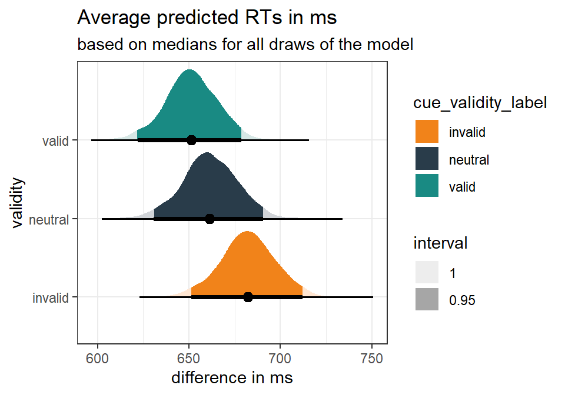

```r
# now gather all the single draws to be able to plot the variance predicted RTs for different validity levels
bestmodel.ef.ef_draws_validity <- bestmodel.ef.model %>%
  emmeans(~ cue_validity_label,
          epred = TRUE)%>%
  gather_emmeans_draws()

theme_set(theme_bw())
g <- ggplot(bestmodel.ef.ef_draws_validity, aes(y = cue_validity_label, x = .value)) +
  stat_halfeye(
    aes(fill = cue_validity_label, fill_ramp = after_stat(level)),
    .width = c(.95, 1),
    position = "dodgejust",
  ) +
  scale_fill_manual(values=c("#F1831A", "#293C4A", "#198A83")) +
  scale_color_manual(values=c("#F1831A", "#293C4A", "#198A83"))+
  labs(
    title = "Average predicted RTs in ms",
    subtitle = "based on medians for all draws of the model",
    fill_ramp = "interval",
    x = "difference in ms",
    y = "validity"
  )

print(g)
```

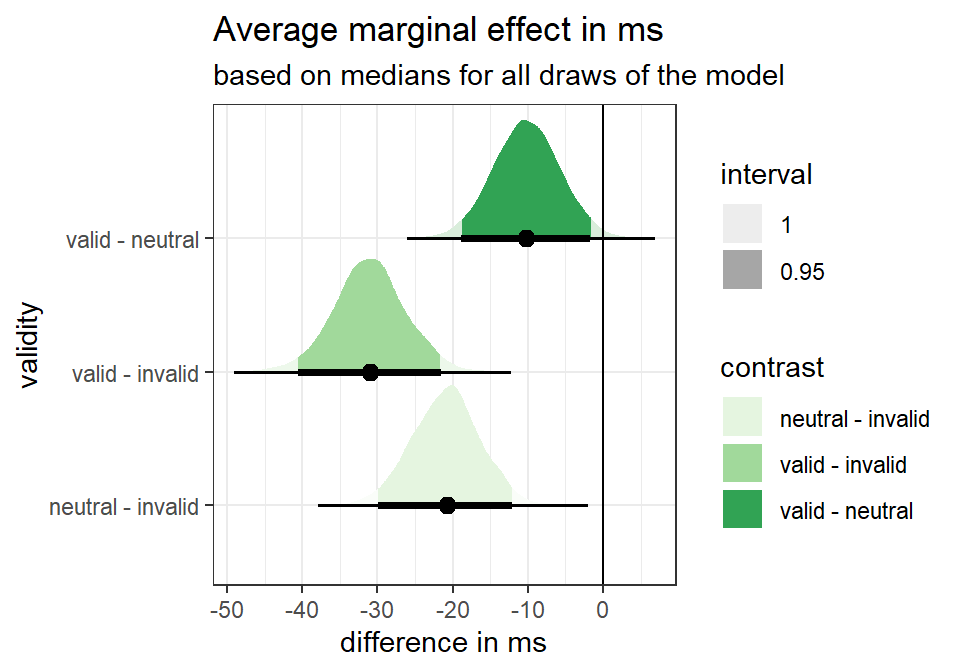

```r
# ggsave(filename = "figures/MarginEffects_PreTarget_FullModelVisAlpha_ValidityEffects.eps",
#        width = 5, height = 3.5,
#        plot = print(g))



# now gather all the single draws to be able to plot the variance of the contrast
bestmodel.ef.ef_draws_validity_contr <- bestmodel.ef.model %>%
  emmeans(~ cue_validity_label,
          epred = TRUE)%>%
  contrast(method = "revpairwise") %>%
  gather_emmeans_draws()

theme_set(theme_bw())
g <- ggplot(bestmodel.ef.ef_draws_validity_contr, aes(y = contrast, x = .value)) +
  stat_halfeye(
    aes(fill = contrast, fill_ramp = after_stat(level)),
    .width = c(.95, 1),
    position = "dodgejust",
  ) +
  geom_vline(xintercept = 0)+
  scale_fill_brewer(palette = "Greens")+
  labs(
    title = "Average marginal effect in ms",
    subtitle = "based on medians for all draws of the model",
    fill_ramp = "interval",
    x = "difference in ms",
    y = "validity"
  )

print(g)
```

```r
# ggsave(filename = "figures/MarginEffects_PreTarget_FullModelVisAlpha_ValidityEffectContrasts.eps",
#        width = 5, height = 3.5,
#        plot = print(g))
```

We now can similarly extract the slopes of the **alpha** and **RT** relationship

```r
# now trying to get the regression line right for the alpha predictors



## alpha contra target
# use range of data from orignal study with varying alpha contra target (in range of original data)
bestmodel.ef.newdata2 <- expand_grid(
  cue_validity_label = c('valid','neutral','invalid'),
  # contra_target = median(bestmodel.ef.data$contra_target),
  contra_nontarget = median(bestmodel.ef.data$contra_nontarget),
  contra_target = seq(min(bestmodel.ef.data$contra_target),max(bestmodel.ef.data$contra_target),1),
  # contra_nontarget = seq(min(bestmodel.ef.data$contra_nontarget),max(bestmodel.ef.data$contra_nontarget),1),
  # subject = as.factor(unique(bestmodel.ef.data$subject))
  subject = as.factor(c(120)) # for a 'new' subject
)

# use 'expected draws' ('epred_draws') as we're more intereste in the expected value of the outcome
# which means we’re more focused on the uncertainty in the model parameters and not necessarily the individual-level residuals
# same as fitte function (only with nicer wrapper)
bestmodel.ef.tidy_exppred2 <- bestmodel.ef.model %>%
  epred_draws(newdata = bestmodel.ef.newdata2, allow_new_levels = TRUE)
head(bestmodel.ef.tidy_exppred2)%>%
  kable(escape = F, digits = c(6,6,6,6,6,6,6,6,6), caption = c("predicted data | alpha contra target")) %>%
  kable_styling("striped", full_width = T, bootstrap_options = c("striped", "hover", "condensed", "responsive",font_size = 8))
```

predicted data | alpha contra target

| cue_validity_label | contra_nontarget | contra_target | subject | .row | .chain | .iteration | .draw | .epred |
| --- | --- | --- | --- | --- | --- | --- | --- | --- |
| valid | -0.15644 | -2.672882 | 120 | 1 | NA | NA | 1 | 668.55475 |
| valid | -0.15644 | -2.672882 | 120 | 1 | NA | NA | 2 | 586.56936 |
| valid | -0.15644 | -2.672882 | 120 | 1 | NA | NA | 3 | 676.65413 |
| valid | -0.15644 | -2.672882 | 120 | 1 | NA | NA | 4 | 725.27999 |
| valid | -0.15644 | -2.672882 | 120 | 1 | NA | NA | 5 | 529.08958 |
| valid | -0.15644 | -2.672882 | 120 | 1 | NA | NA | 6 | 778.73614 |

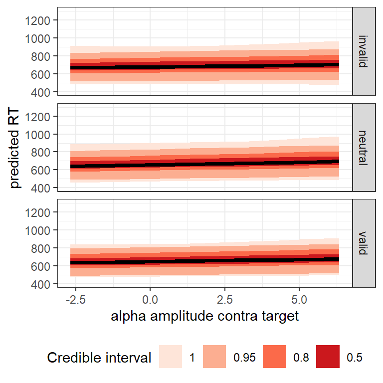

```r
theme_set(theme_bw())
g <- ggplot(bestmodel.ef.tidy_exppred2, aes(x = contra_target, y = .epred)) +
  stat_lineribbon(.width = c(0.5, 0.8, 0.95, 1)) +
  scale_fill_brewer(palette = "Reds") +
  facet_grid(cue_validity_label~.)+
  labs(x = "alpha amplitude contra target", y = "predicted RT",
       fill = "Credible interval") +
  ylim(c(400,1300))+
  theme(legend.position = "bottom")

print(g)
```

```r
# ggsave(filename = "figures/MarginEffects_PreTarget_FullModelVisAlpha_AlphaContraTarget_Slopes.eps",
#        width = 4, height = 4,
#        plot = print(g))


## alpha contra nontarget
# use range of data from orignal study with varying alpha contra target (in range of original data)
bestmodel.ef.newdata5 <- expand_grid(
  cue_validity_label = c('valid','neutral','invalid'),
  contra_target = median(bestmodel.ef.data$contra_target),
  # contra_nontarget = median(bestmodel.ef.data$contra_nontarget),
  # contra_target = seq(min(bestmodel.ef.data$contra_target),max(bestmodel.ef.data$contra_target),1),
  contra_nontarget = seq(min(bestmodel.ef.data$contra_nontarget),max(bestmodel.ef.data$contra_nontarget),1),
  # subject = as.factor(unique(bestmodel.ef.data$subject))
  subject = as.factor(c(120)) # for a 'new' subject
)

# use 'expected draws' ('epred_draws') as we're more intereste in the expected value of the outcome
# which means we’re more focused on the uncertainty in the model parameters and not necessarily the individual-level residuals
# same as fitte function (only with nicer wrapper)
bestmodel.ef.tidy_exppred3 <- bestmodel.ef.model %>%
  epred_draws(newdata = bestmodel.ef.newdata5, allow_new_levels = TRUE)
head(bestmodel.ef.tidy_exppred3)%>%
  kable(escape = F, digits = c(6,6,6,6,6,6,6,6,6), caption = c("predicted data | alpha contra non target")) %>%
  kable_styling("striped", full_width = T, bootstrap_options = c("striped", "hover", "condensed", "responsive",font_size = 8))
```

predicted data | alpha contra non target

| cue_validity_label | contra_target | contra_nontarget | subject | .row | .chain | .iteration | .draw | .epred |
| --- | --- | --- | --- | --- | --- | --- | --- | --- |
| valid | -0.151394 | -2.668772 | 120 | 1 | NA | NA | 1 | 642.56770 |
| valid | -0.151394 | -2.668772 | 120 | 1 | NA | NA | 2 | 631.68466 |
| valid | -0.151394 | -2.668772 | 120 | 1 | NA | NA | 3 | 692.43960 |
| valid | -0.151394 | -2.668772 | 120 | 1 | NA | NA | 4 | 627.02069 |
| valid | -0.151394 | -2.668772 | 120 | 1 | NA | NA | 5 | 608.54501 |
| valid | -0.151394 | -2.668772 | 120 | 1 | NA | NA | 6 | 628.76732 |

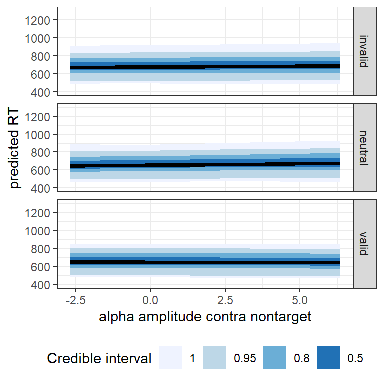

```r
theme_set(theme_bw())
g <- ggplot(bestmodel.ef.tidy_exppred3, aes(x = contra_nontarget, y = .epred)) +
  stat_lineribbon(.width = c(0.5, 0.8, 0.95, 1)) +
  scale_fill_brewer(palette = "Blues") +
  facet_grid(cue_validity_label~.)+
  labs(x = "alpha amplitude contra nontarget", y = "predicted RT",
       fill = "Credible interval") +
  ylim(c(400,1300))+
  theme(legend.position = "bottom")

print(g)
```

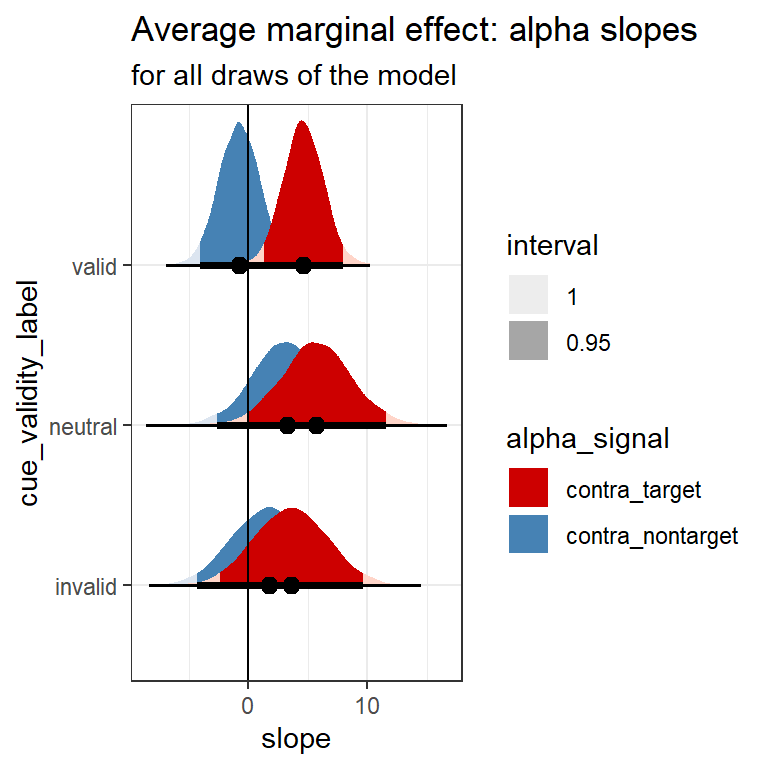

```r
# ggsave(filename = "figures/MarginEffects_PreTarget_FullModelVisAlpha_AlphaContraNonTarget_Slopes.eps",
#        width = 4, height = 4,
#        plot = print(g))





# now lets get the slop of the modulation by alpha
bestmodel.ef.slope_contraTarget <- bestmodel.ef.model %>%
  emtrends(~ cue_validity_label, # 1 means, we want the average slop
           var = "contra_target",
           epred = TRUE) %>%
  gather_emmeans_draws()

bestmodel.ef.slope_contraNontarget <- bestmodel.ef.model %>%
  emtrends(~ cue_validity_label, # 1 means, we want the average slop
           var = "contra_nontarget",
           epred = TRUE) %>%
  gather_emmeans_draws()

bestmodel.ef.slopes_alpha <- bind_rows(
  "contra_target" = bestmodel.ef.slope_contraTarget,
  "contra_nontarget" = bestmodel.ef.slope_contraNontarget,
  .id = "alpha_signal") %>%
  mutate(alpha_signal = fct_inorder(alpha_signal))

theme_set(theme_bw())
g<-ggplot(bestmodel.ef.slopes_alpha, aes( x = .value, y=cue_validity_label)) +
  stat_halfeye(
    aes(fill = alpha_signal, fill_ramp = after_stat(level)),
    .width = c(.95, 1),
  ) +
  # stat_dots(aes(fill = alpha_signal,color = alpha_signal, fill_ramp = after_stat(level), colour_ramp = after_stat(level)),
  #           .width = c(.95, 1))+
  geom_vline(xintercept = 0)+
  # facet_grid(cue_validity_label~.)+
  scale_fill_manual(values=c("red3","steelblue")) +
  scale_color_manual(values=c("red3", "steelblue"))+
  labs(
    title = "Average marginal effect: alpha slopes",
    subtitle = "for all draws of the model",
    fill_ramp = "interval",
    colour_ramp = "interval",
    x = "slope"
  )

print(g)
```

```r
# ggsave(filename = "figures/MarginEffects_PreTarget_FullModelVisAlpha_Alpha_SlopeDistr.eps",
#        width = 4, height = 4,
#        plot = print(g))


bestmodel.ef.slope_contraTarget %>% median_hdi() %>%
  kable(escape = F, digits = c(3,3,3,3,6,6,6,6,6), caption = c("alpha contratarget: mean and CI")) %>%
  kable_styling("striped", full_width = T, bootstrap_options = c("striped", "hover", "condensed", "responsive",font_size = 8))
```

alpha contratarget: mean and CI

| cue_validity_label | .value | .lower | .upper | .width | .point | .interval |
| --- | --- | --- | --- | --- | --- | --- |
| invalid | 3.595 | -2.318 | 9.601 | 0.95 | median | hdi |
| neutral | 5.715 | 0.233 | 11.756 | 0.95 | median | hdi |
| valid | 4.592 | 1.114 | 7.655 | 0.95 | median | hdi |

```r
bestmodel.ef.slope_contraNontarget %>% median_hdi() %>%
  kable(escape = F, digits = c(3,3,3,3,6,6,6,6,6), caption = c("alpha contranontarget: mean and CI")) %>%
  kable_styling("striped", full_width = T, bootstrap_options = c("striped", "hover", "condensed", "responsive",font_size = 8))
```

alpha contranontarget: mean and CI

| cue_validity_label | .value | .lower | .upper | .width | .point | .interval |
| --- | --- | --- | --- | --- | --- | --- |
| invalid | 1.711 | -4.084 | 7.897 | 0.95 | median | hdi |
| neutral | 3.282 | -2.994 | 8.507 | 0.95 | median | hdi |
| valid | -0.786 | -4.148 | 2.361 | 0.95 | median | hdi |

### Extract marginal effects for pre-target motor alpha model

Now for illustrating the whole picture, lets plot the motor alpha model

**‘RT ~ Cue x motor_alpha_Targ + ( cue | subjects)’**

```r
# based on https://www.andrewheiss.com/blog/2021/11/10/ame-bayes-re-guide/
# which model to use?
bestmodel.ef.model <- fit_validity_x_motoralpha
# what is the data of the model?
bestmodel.ef.data <- bestmodel.ef.model$data

# see data
#head(bestmodel.ef.data)

# show effects of the model
tidy(bestmodel.ef.model)%>%
  kable(escape = F, digits = c(6,6,6,6,6,6,6,6,6), caption = c("effects of best model")) %>%
  kable_styling("striped", full_width = T, bootstrap_options = c("striped", "hover", "condensed", "responsive",font_size = 8))
```

effects of best model

| effect | component | group | term | estimate | std.error | conf.low | conf.high |
| --- | --- | --- | --- | --- | --- | --- | --- |
| fixed | cond | NA | (Intercept) | 6.205404 | 0.033171 | 6.139175 | 6.269521 |
| fixed | cond | NA | cue_validity_labelneutral | -0.041635 | 0.009032 | -0.058734 | -0.023956 |
| fixed | cond | NA | cue_validity_labelvalid | -0.062278 | 0.009512 | -0.080806 | -0.042951 |
| fixed | cond | NA | pre_target_malpha_contra_target | 0.005159 | 0.005767 | -0.006244 | 0.015926 |
| fixed | cond | NA | cue_validity_labelneutral:pre_target_malpha_contra_target | -0.001678 | 0.008376 | -0.017740 | 0.014803 |
| fixed | cond | NA | cue_validity_labelvalid:pre_target_malpha_contra_target | 0.003338 | 0.006645 | -0.009576 | 0.016622 |
| ran_pars | cond | subject | sd__(Intercept) | 0.153319 | 0.023273 | 0.116444 | 0.205698 |
| ran_pars | cond | subject | sd__cue_validity_labelneutral | 0.017542 | 0.011303 | 0.000871 | 0.043583 |
| ran_pars | cond | subject | sd__cue_validity_labelvalid | 0.033435 | 0.009839 | 0.015323 | 0.054446 |
| ran_pars | cond | subject | cor__(Intercept).cue_validity_labelneutral | 0.231744 | 0.407572 | -0.630582 | 0.897258 |
| ran_pars | cond | subject | cor__(Intercept).cue_validity_labelvalid | -0.080409 | 0.259237 | -0.557360 | 0.436605 |
| ran_pars | cond | subject | cor__cue_validity_labelneutral.cue_validity_labelvalid | 0.371640 | 0.425001 | -0.631367 | 0.940392 |
| ran_pars | cond | Residual | sd__Observation | 0.262509 | 0.004551 | 0.253266 | 0.271166 |

We then create a new data set with an alpha amplitude value fixed at the median of the original data, to be able to illustrate the distribution of the marginal means and their effect for the attentional cue, i.e. the factor **validity**

Based on the new data we can extract **predicted values** or **expected predicted values**. The former also includes the uncertainty for each individual observation (e.g., observational-level residual variance) of each prediction. We’re however more interested in the latter, which more focusses on the uncertainty in the model parameters and not necessarily the individual-level residuals.

```r
# use range of data from orignal study
bestmodel.ef.newdata3 <- expand_grid(
  cue_validity_label = c('valid','neutral','invalid'),
  pre_target_malpha_contra_target = median(bestmodel.ef.data$pre_target_malpha_contra_target),
  # contra_nontarget = median(bestmodel.ef.data$contra_nontarget),
  # contra_target = seq(min(bestmodel.ef.data$contra_target),max(bestmodel.ef.data$contra_target),1),
  # contra_nontarget = seq(min(bestmodel.ef.data$contra_nontarget),max(bestmodel.ef.data$contra_nontarget),1),
  # subject = as.factor(unique(bestmodel.ef.data$subject))
  subject = as.factor(c(120)) # for a 'new' subject
)

# use 'predicted_draws' to draw from posterior predictive distribution
# this still incorporates variance of each individual observation in the model
# we may not want to have this around for marginal effects, awe we're more focused on the expected value
bestmodel.ef.tidy_pred <- bestmodel.ef.model %>%
  predicted_draws(newdata = bestmodel.ef.newdata3, allow_new_levels = TRUE)
head(bestmodel.ef.tidy_pred)%>%
  kable(escape = F, digits = c(6,6,6,6,6,6,6,6,6), caption = c("predicted data")) %>%
  kable_styling("striped", full_width = T, bootstrap_options = c("striped", "hover", "condensed", "responsive",font_size = 8))
```

predicted data

| cue_validity_label | pre_target_malpha_contra_target | subject | .row | .chain | .iteration | .draw | .prediction |
| --- | --- | --- | --- | --- | --- | --- | --- |
| valid | -0.178677 | 120 | 1 | NA | NA | 1 | 465.86079 |
| valid | -0.178677 | 120 | 1 | NA | NA | 2 | 901.21030 |
| valid | -0.178677 | 120 | 1 | NA | NA | 3 | 675.97831 |
| valid | -0.178677 | 120 | 1 | NA | NA | 4 | 622.17191 |
| valid | -0.178677 | 120 | 1 | NA | NA | 5 | 552.77577 |
| valid | -0.178677 | 120 | 1 | NA | NA | 6 | 635.48164 |

```r
# use 'expected draws' ('epred_draws') as we're more intereste in the expected value of the outcome
# which means we’re more focused on the uncertainty in the model parameters and not necessarily the individual-level residuals
# same as fitte function (only with nicer wrapper)
bestmodel.ef.tidy_exppred <- bestmodel.ef.model %>%
  epred_draws(newdata = bestmodel.ef.newdata3, allow_new_levels = TRUE)
head(bestmodel.ef.tidy_exppred)%>%
  kable(escape = F, digits = c(6,6,6,6,6,6,6,6,6), caption = c("predicted data")) %>%
  kable_styling("striped", full_width = T, bootstrap_options = c("striped", "hover", "condensed", "responsive",font_size = 8))
```

predicted data

| cue_validity_label | pre_target_malpha_contra_target | subject | .row | .chain | .iteration | .draw | .epred |
| --- | --- | --- | --- | --- | --- | --- | --- |
| valid | -0.178677 | 120 | 1 | NA | NA | 1 | 621.35533 |
| valid | -0.178677 | 120 | 1 | NA | NA | 2 | 684.98947 |
| valid | -0.178677 | 120 | 1 | NA | NA | 3 | 730.35563 |
| valid | -0.178677 | 120 | 1 | NA | NA | 4 | 486.49302 |
| valid | -0.178677 | 120 | 1 | NA | NA | 5 | 637.34301 |
| valid | -0.178677 | 120 | 1 | NA | NA | 6 | 491.89021 |

Now with the `emmeans` package, we can extract the distribution of median RTs derived from the predicted RT-value distributions of each single draw/simulation. We can also directly calculate contrasts and derive the 95%-CI of the effects.

```r
# now we want to see the effects using emmeans
# check cue validity effect via pairwise comparisons
# first the emmeans (point estimate = median of distrbution)
bestmodel.ef.model %>%
  emmeans(~ cue_validity_label,
          epred = TRUE)%>%
  kable(escape = F, digits = c(3,3,3,6,3,3,3,3,3),
        caption = c("average marginal effect | point measure = median of RT in ms")) %>%
  # kable_classic(full_width = F) %>%
  column_spec(1, bold = T)%>%
  kable_styling("striped", full_width = T, bootstrap_options = c("striped", "hover", "condensed", "responsive",font_size = 8))
```

average marginal effect | point measure = median of RT in ms

| cue_validity_label | emmean | lower.HPD | upper.HPD |
| --- | --- | --- | --- |
| invalid | 681.333 | 653.560 | 713.51031 |
| neutral | 660.564 | 631.903 | 690.90921 |
| valid | 650.340 | 622.715 | 678.08056 |

```r
# pairwise comparisons
bestmodel.ef.model %>%
  emmeans(~ cue_validity_label,
          epred = TRUE)%>%
  contrast(method = "revpairwise")%>%
  kable(escape = F, digits = c(3,3,3,6,3,3,3,3,3),
        caption = c("average marginal effect differences | point measure = median of RT in ms")) %>%
  # kable_classic(full_width = F) %>%
  column_spec(1, bold = T)%>%
  kable_styling("striped", full_width = T, bootstrap_options = c("striped", "hover", "condensed", "responsive",font_size = 8))
```

average marginal effect differences | point measure = median of RT in ms

| contrast | estimate | lower.HPD | upper.HPD |
| --- | --- | --- | --- |
| neutral - invalid | -20.868 | -29.540 | -12.289820 |
| valid - invalid | -30.938 | -39.968 | -21.210954 |
| valid - neutral | -10.117 | -18.565 | -1.189753 |

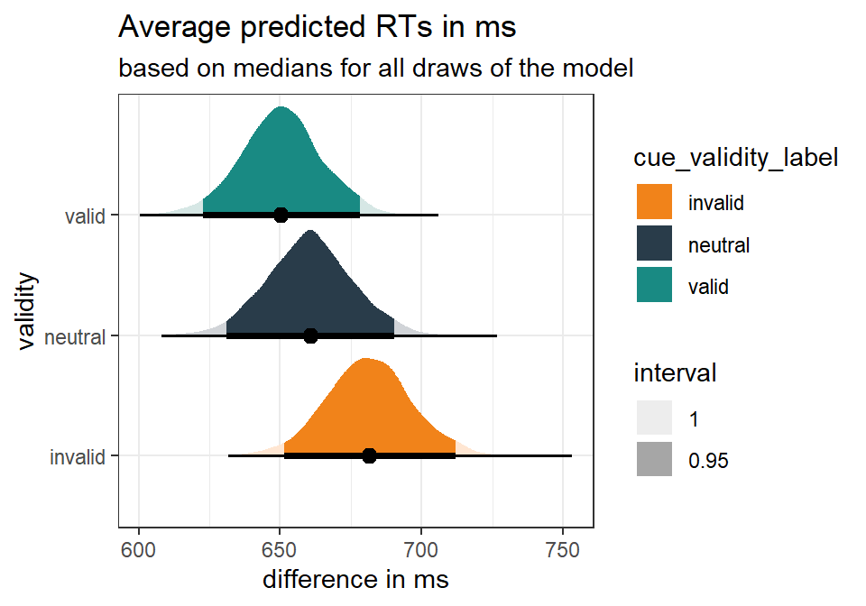

```r
# now gather all the single draws to be able to plot the variance predicted RTs for different validity levels
bestmodel.ef.ef_draws_validity <- bestmodel.ef.model %>%
  emmeans(~ cue_validity_label,
          epred = TRUE)%>%
  gather_emmeans_draws()

theme_set(theme_bw())
g <- ggplot(bestmodel.ef.ef_draws_validity, aes(y = cue_validity_label, x = .value)) +
  stat_halfeye(
    aes(fill = cue_validity_label, fill_ramp = after_stat(level)),
    .width = c(.95, 1),
    position = "dodgejust",
  ) +
  scale_fill_manual(values=c("#F1831A", "#293C4A", "#198A83")) +
  scale_color_manual(values=c("#F1831A", "#293C4A", "#198A83"))+
  labs(
    title = "Average predicted RTs in ms",
    subtitle = "based on medians for all draws of the model",
    fill_ramp = "interval",
    x = "difference in ms",
    y = "validity"
  )
print(g)
```

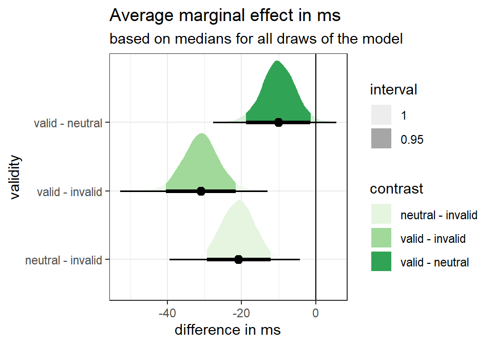

```r
# ggsave(filename = "figures/MarginEffects_PreTarget_FullModelMotAlpha_ValidityEffects.eps",
#        width = 5, height = 3.5,
#        plot = print(g))



# now gather all the single draws to be able to plot the variance of the contrast
bestmodel.ef.ef_draws_validity_contr <- bestmodel.ef.model %>%
  emmeans(~ cue_validity_label,
          epred = TRUE)%>%
  contrast(method = "revpairwise") %>%
  gather_emmeans_draws()

theme_set(theme_bw())
g <- ggplot(bestmodel.ef.ef_draws_validity_contr, aes(y = contrast, x = .value)) +
  stat_halfeye(
    aes(fill = contrast, fill_ramp = after_stat(level)),
    .width = c(.95, 1),
    position = "dodgejust",
  ) +
  geom_vline(xintercept = 0)+
  scale_fill_brewer(palette = "Greens")+
  labs(
    title = "Average marginal effect in ms",
    subtitle = "based on medians for all draws of the model",
    fill_ramp = "interval",
    x = "difference in ms",
    y = "validity"
  )

print(g)
```

```r
# ggsave(filename = "figures/MarginEffects_PreTarget_FullModelMotAlpha_ValidityEffectContrasts.eps",
#        width = 5, height = 3.5,
#        plot = print(g))
```

We now can similarly extract the slopes of the **alpha** and **RT** relationship

```r
# now trying to get the regression line right for the alpha predictors


## alpha contra target
# use range of data from orignal study with varying alpha contra target (in range of original data)
bestmodel.ef.newdata4 <- expand_grid(
  cue_validity_label = c('valid','neutral','invalid'),
  pre_target_malpha_contra_target = seq(min(bestmodel.ef.data$pre_target_malpha_contra_target),max(bestmodel.ef.data$pre_target_malpha_contra_target),1),
  subject = as.factor(c(120)) # for a 'new' subject
)

# use 'expected draws' ('epred_draws') as we're more intereste in the expected value of the outcome
# which means we’re more focused on the uncertainty in the model parameters and not necessarily the individual-level residuals
# same as fitte function (only with nicer wrapper)
bestmodel.ef.tidy_exppred2 <- bestmodel.ef.model %>%
  epred_draws(newdata = bestmodel.ef.newdata4, allow_new_levels = TRUE)
head(bestmodel.ef.tidy_exppred2)%>%
  kable(escape = F, digits = c(6,6,6,6,6,6,6,6,6), caption = c("predicted data")) %>%
  kable_styling("striped", full_width = T, bootstrap_options = c("striped", "hover", "condensed", "responsive",font_size = 8))
```

predicted data

| cue_validity_label | pre_target_malpha_contra_target | subject | .row | .chain | .iteration | .draw | .epred |
| --- | --- | --- | --- | --- | --- | --- | --- |
| valid | -2.980398 | 120 | 1 | NA | NA | 1 | 498.16774 |
| valid | -2.980398 | 120 | 1 | NA | NA | 2 | 718.96246 |
| valid | -2.980398 | 120 | 1 | NA | NA | 3 | 599.74867 |
| valid | -2.980398 | 120 | 1 | NA | NA | 4 | 601.01241 |
| valid | -2.980398 | 120 | 1 | NA | NA | 5 | 670.15596 |
| valid | -2.980398 | 120 | 1 | NA | NA | 6 | 682.72400 |

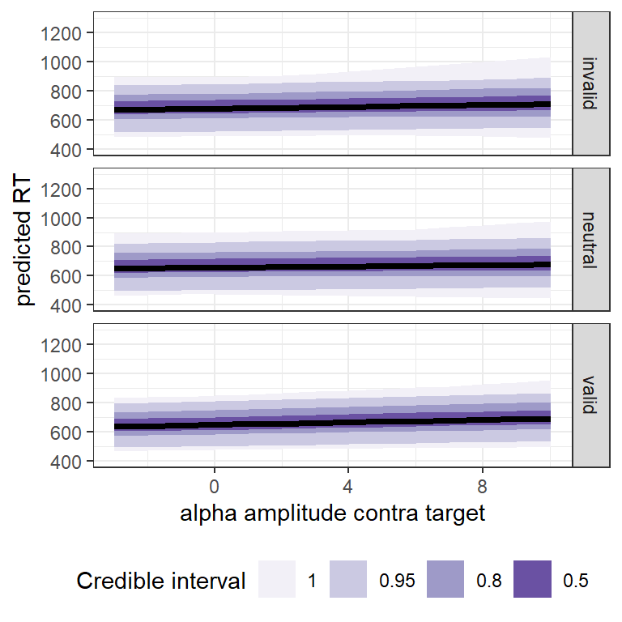

```r
theme_set(theme_bw())
g <- ggplot(bestmodel.ef.tidy_exppred2, aes(x = pre_target_malpha_contra_target, y = .epred)) +
  stat_lineribbon(.width = c(0.5, 0.8, 0.95, 1)) +
  scale_fill_brewer(palette = "Purples") +
  facet_grid(cue_validity_label~.)+
  labs(x = "alpha amplitude contra target", y = "predicted RT",
       fill = "Credible interval") +
  ylim(c(400,1300))+
  theme(legend.position = "bottom")

# now lets get the slop of the modulation by alpha
bestmodel.ef.slope_contraTarget <- bestmodel.ef.model %>%
  emtrends(~ cue_validity_label, # 1 means, we want the average slop
           var = "pre_target_malpha_contra_target",
           epred = TRUE) %>%
  gather_emmeans_draws()

print(g)
```

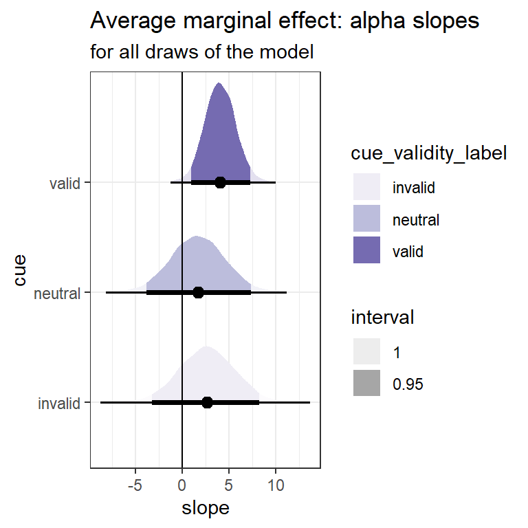

```r
# ggsave(filename = "figures/MarginEffects_PreTarget_FullModelMotAlpha_MotAlpha_Slopes.eps",
#        width = 4, height = 4,
#        plot = print(g))



theme_set(theme_bw())
g <- ggplot(bestmodel.ef.slope_contraTarget, aes( x = .value, y=cue_validity_label)) +
  stat_halfeye(
    aes( fill = cue_validity_label, fill_ramp = after_stat(level)),
    .width = c(.95, 1),
  ) +
  # stat_dots(aes(fill = alpha_signal,color = alpha_signal, fill_ramp = after_stat(level), colour_ramp = after_stat(level)),
  #           .width = c(.95, 1))+
  geom_vline(xintercept = 0)+
  # scale_fill_manual(values=c("red3")) +
  scale_color_brewer(palette = "Purples") +
  scale_fill_brewer(palette = "Purples") +
  labs(
    title = "Average marginal effect: alpha slopes",
    subtitle = "for all draws of the model",
    fill_ramp = "interval",
    colour_ramp = "interval",
    x = "slope",
    y = "cue"
  )

print(g)
```

```r
# ggsave(filename = "figures/MarginEffects_PreTarget_FullModelMotAlpha_MotAlpha_SlopeDistr.eps",
#        width = 4, height = 4,
#        plot = print(g))


bestmodel.ef.slope_contraTarget %>% median_hdi() %>%
  kable(escape = F, digits = c(3,3,3,3,6,6,6,6,6), caption = c("alpha slope: mean and CI")) %>%
  kable_styling("striped", full_width = T, bootstrap_options = c("striped", "hover", "condensed", "responsive",font_size = 8))
```

alpha slope: mean and CI

| cue_validity_label | .value | .lower | .upper | .width | .point | .interval |
| --- | --- | --- | --- | --- | --- | --- |
| invalid | 2.643 | -3.136 | 8.268 | 0.95 | median | hdi |
| neutral | 1.694 | -3.838 | 7.302 | 0.95 | median | hdi |
| valid | 4.070 | 1.070 | 7.388 | 0.95 | median | hdi |

### Extract marginal effects for pre-target SSVEP interaction model

Now for illustrating the whole picture, lets plot the SSVEP full model

**‘RT ~ Cue x target_SSVEP + ( cue | subjects)’**

```r
# based on https://www.andrewheiss.com/blog/2021/11/10/ame-bayes-re-guide/
# there is some debate whether the p-value approach to model selection is appropriate or whether one should simply report the full model: https://discourse.mc-stan.org/t/if-elpd-diff-se-diff-2-is-this-noteworthy/20549/20

# which model to use?
bestmodel.ef.model <- fit_validity_x_SSVEP
# what is the data of the model?
bestmodel.ef.data <- bestmodel.ef.model$data

# see data
#head(bestmodel.ef.data)

# show effects of the model
tidy(bestmodel.ef.model)%>%
  kable(escape = F, digits = c(6,6,6,6,6,6,6,6,6), caption = c("effects of best model")) %>%
  kable_styling("striped", full_width = T, bootstrap_options = c("striped", "hover", "condensed", "responsive",font_size = 8))
```

effects of best model

| effect | component | group | term | estimate | std.error | conf.low | conf.high |
| --- | --- | --- | --- | --- | --- | --- | --- |
| fixed | cond | NA | (Intercept) | 6.206897 | 0.034318 | 6.138946 | 6.273671 |
| fixed | cond | NA | cue_validity_labelneutral | -0.041521 | 0.009004 | -0.058925 | -0.023392 |
| fixed | cond | NA | cue_validity_labelvalid | -0.062043 | 0.009313 | -0.080828 | -0.043461 |
| fixed | cond | NA | post_cue_SSVEP_contra_target | -0.001114 | 0.006682 | -0.014403 | 0.012192 |
| fixed | cond | NA | cue_validity_labelneutral:post_cue_SSVEP_contra_target | 0.005417 | 0.008586 | -0.011474 | 0.022174 |
| fixed | cond | NA | cue_validity_labelvalid:post_cue_SSVEP_contra_target | -0.001409 | 0.007528 | -0.016399 | 0.013647 |
| ran_pars | cond | subject | sd__(Intercept) | 0.155420 | 0.023844 | 0.115855 | 0.208742 |
| ran_pars | cond | subject | sd__cue_validity_labelneutral | 0.017043 | 0.011032 | 0.000820 | 0.041140 |
| ran_pars | cond | subject | sd__cue_validity_labelvalid | 0.033197 | 0.010244 | 0.013707 | 0.054787 |
| ran_pars | cond | subject | cor__(Intercept).cue_validity_labelneutral | 0.214650 | 0.417074 | -0.708642 | 0.895136 |
| ran_pars | cond | subject | cor__(Intercept).cue_validity_labelvalid | -0.064628 | 0.272273 | -0.562199 | 0.495773 |
| ran_pars | cond | subject | cor__cue_validity_labelneutral.cue_validity_labelvalid | 0.351261 | 0.441387 | -0.667895 | 0.937736 |
| ran_pars | cond | Residual | sd__Observation | 0.262341 | 0.004562 | 0.253203 | 0.271063 |

We then create a new data set with an alpha amplitude value fixed at the median of the original data, to be able to illustrate the distribution of the marginal means and their effect for the attentional cue, i.e. the factor **validity**

Based on the new data we can extract **predicted values** or **expected predicted values**. The former also includes the uncertainty for each individual observation (e.g., observational-level residual variance) of each prediction. We’re however more interested in the latter, which more focusses on the uncertainty in the model parameters and not necessarily the individual-level residuals.

```r
# use range of data from orignal study
bestmodel.ef.newdata1 <- expand_grid(
  cue_validity_label = c('valid','neutral','invalid'),
  post_cue_SSVEP_contra_target      = median(bestmodel.ef.data$post_cue_SSVEP_contra_target),
  # contra_nontarget = median(bestmodel.ef.data$post_cue_SSVEP_contra_targe),
  # contra_target = seq(min(bestmodel.ef.data$contra_target),max(bestmodel.ef.data$contra_target),1),
  # contra_nontarget = seq(min(bestmodel.ef.data$contra_nontarget),max(bestmodel.ef.data$contra_nontarget),1),
  # subject = as.factor(unique(bestmodel.ef.data$subject))
  subject = as.factor(c(120)) # for a 'new' subject
)

# use 'predicted_draws' to draw from posterior predictive distribution
# this still incorporates variance of each individual observation in the model
# we may not want to have this around for marginal effects, awe we're more focused on the expected value
bestmodel.ef.tidy_pred <- bestmodel.ef.model %>%
  predicted_draws(newdata = bestmodel.ef.newdata1, allow_new_levels = TRUE)
head(bestmodel.ef.tidy_pred)%>%
  kable(escape = F, digits = c(6,6,6,6,6,6,6,6,6), caption = c("predicted data")) %>%
  kable_styling("striped", full_width = T, bootstrap_options = c("striped", "hover", "condensed", "responsive",font_size = 8))
```

predicted data

| cue_validity_label | post_cue_SSVEP_contra_target | subject | .row | .chain | .iteration | .draw | .prediction |
| --- | --- | --- | --- | --- | --- | --- | --- |
| valid | -0.197166 | 120 | 1 | NA | NA | 1 | 575.49590 |
| valid | -0.197166 | 120 | 1 | NA | NA | 2 | 918.20591 |
| valid | -0.197166 | 120 | 1 | NA | NA | 3 | 592.22988 |
| valid | -0.197166 | 120 | 1 | NA | NA | 4 | 1165.82059 |
| valid | -0.197166 | 120 | 1 | NA | NA | 5 | 564.61136 |
| valid | -0.197166 | 120 | 1 | NA | NA | 6 | 901.30094 |

```r
# use 'expected draws' ('epred_draws') as we're more intereste in the expected value of the outcome
# which means we’re more focused on the uncertainty in the model parameters and not necessarily the individual-level residuals
# same as fitte function (only with nicer wrapper)
bestmodel.ef.tidy_exppred <- bestmodel.ef.model %>%
  epred_draws(newdata = bestmodel.ef.newdata1, allow_new_levels = TRUE)
head(bestmodel.ef.tidy_exppred)%>%
  kable(escape = F, digits = c(6,6,6,6,6,6,6,6,6), caption = c("predicted data")) %>%
  kable_styling("striped", full_width = T, bootstrap_options = c("striped", "hover", "condensed", "responsive",font_size = 8))
```

predicted data

| cue_validity_label | post_cue_SSVEP_contra_target | subject | .row | .chain | .iteration | .draw | .epred |
| --- | --- | --- | --- | --- | --- | --- | --- |
| valid | -0.197166 | 120 | 1 | NA | NA | 1 | 650.79066 |
| valid | -0.197166 | 120 | 1 | NA | NA | 2 | 581.97615 |
| valid | -0.197166 | 120 | 1 | NA | NA | 3 | 615.84344 |
| valid | -0.197166 | 120 | 1 | NA | NA | 4 | 736.29443 |
| valid | -0.197166 | 120 | 1 | NA | NA | 5 | 646.34259 |
| valid | -0.197166 | 120 | 1 | NA | NA | 6 | 736.24889 |

Now with the `emmeans` package, we can extract the distribution of median RTs derived from the predicted RT-value distributions of each single draw/simulation. We can also directly calculate contrasts and derive the 95%-CI of the effects.

```r
# now we want to see the effects using emmeans
# check cue validity effect via pairwise comparisons
# first the emmeans (point estimate = median of distrbution)
bestmodel.ef.model %>%
  emmeans(~ cue_validity_label,
          epred = TRUE)%>%
  kable(escape = F, digits = c(3,3,3,6,3,3,3,3,3),
        caption = c("average marginal effect | point measure = median of RT in ms")) %>%
  # kable_classic(full_width = F) %>%
  column_spec(1, bold = T)%>%
  kable_styling("striped", full_width = T, bootstrap_options = c("striped", "hover", "condensed", "responsive",font_size = 8))
```

average marginal effect | point measure = median of RT in ms

| cue_validity_label | emmean | lower.HPD | upper.HPD |
| --- | --- | --- | --- |
| invalid | 681.461 | 648.568 | 713.11344 |
| neutral | 660.412 | 627.991 | 690.70586 |
| valid | 650.575 | 619.210 | 678.19265 |

```r
# pairwise comparisons
bestmodel.ef.model %>%
  emmeans(~ cue_validity_label,
          epred = TRUE)%>%
  contrast(method = "revpairwise")%>%
  kable(escape = F, digits = c(3,3,3,6,3,3,3,3,3),
        caption = c("average marginal effect differences | point measure = median of RT in ms")) %>%
  # kable_classic(full_width = F) %>%
  column_spec(1, bold = T)%>%
  kable_styling("striped", full_width = T, bootstrap_options = c("striped", "hover", "condensed", "responsive",font_size = 8))
```

average marginal effect differences | point measure = median of RT in ms

| contrast | estimate | lower.HPD | upper.HPD |
| --- | --- | --- | --- |
| neutral - invalid | -20.877 | -29.354 | -11.286145 |
| valid - invalid | -30.837 | -40.277 | -21.686460 |
| valid - neutral | -9.987 | -18.692 | -1.266304 |

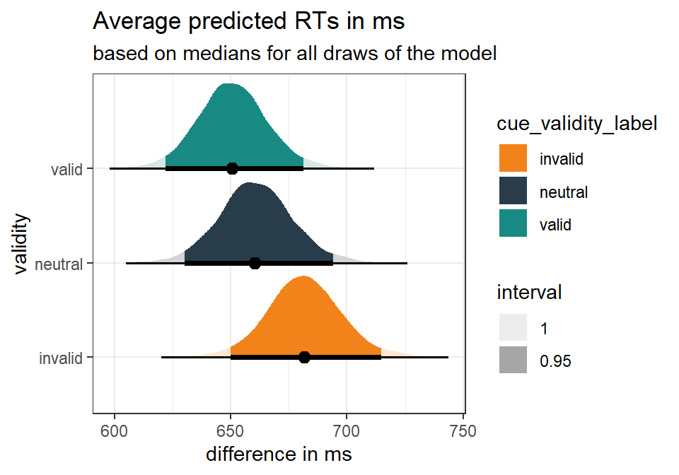

```r
# now gather all the single draws to be able to plot the variance predicted RTs for different validity levels
bestmodel.ef.ef_draws_validity <- bestmodel.ef.model %>%
  emmeans(~ cue_validity_label,
          epred = TRUE)%>%
  gather_emmeans_draws()

theme_set(theme_bw())
g <- ggplot(bestmodel.ef.ef_draws_validity, aes(y = cue_validity_label, x = .value)) +
  stat_halfeye(
    aes(fill = cue_validity_label, fill_ramp = after_stat(level)),
    .width = c(.95, 1),
    position = "dodgejust",
  ) +
  scale_fill_manual(values=c("#F1831A", "#293C4A", "#198A83")) +
  scale_color_manual(values=c("#F1831A", "#293C4A", "#198A83"))+
  labs(
    title = "Average predicted RTs in ms",
    subtitle = "based on medians for all draws of the model",
    fill_ramp = "interval",
    x = "difference in ms",
    y = "validity"
  )

print(g)
```

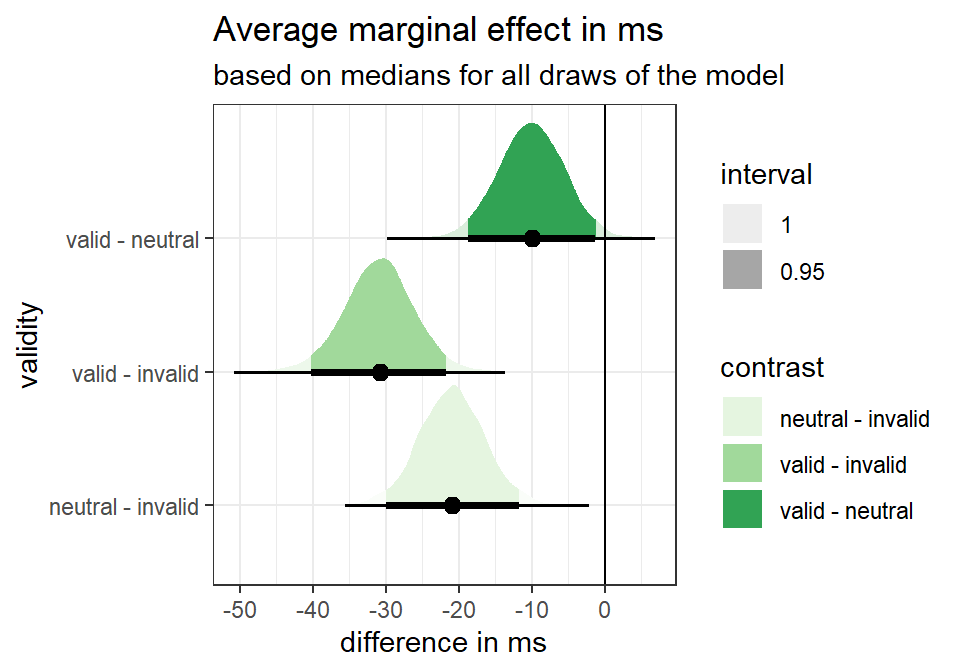

```r
# ggsave(filename = "figures/MarginEffects_PreTarget_FullModelSSVEP_ValidityEffects.eps",
#        width = 5, height = 3.5,
#        plot = print(g))
#


# now gather all the single draws to be able to plot the variance of the contrast
bestmodel.ef.ef_draws_validity_contr <- bestmodel.ef.model %>%
  emmeans(~ cue_validity_label,
          epred = TRUE)%>%
  contrast(method = "revpairwise") %>%
  gather_emmeans_draws()

theme_set(theme_bw())
g<-ggplot(bestmodel.ef.ef_draws_validity_contr, aes(y = contrast, x = .value)) +
  stat_halfeye(
    aes(fill = contrast, fill_ramp = after_stat(level)),
    .width = c(.95, 1),
    position = "dodgejust",
  ) +
  geom_vline(xintercept = 0)+
  scale_fill_brewer(palette = "Greens")+
  labs(
    title = "Average marginal effect in ms",
    subtitle = "based on medians for all draws of the model",
    fill_ramp = "interval",
    x = "difference in ms",
    y = "validity"
  )

print(g)
```

```r
# ggsave(filename = "figures/MarginEffects_PreTarget_FullModelSSVEP_ValidityEffectContrasts.eps",
#        width = 5, height = 3.5,
#        plot = print(g))
```

We now can similarly extract the slopes of the **alpha** and **RT** relationship

```r
# now trying to get the regression line right for the alpha predictors


## SSVEP contra target
# use range of data from orignal study with varying alpha contra target (in range of original data)
bestmodel.ef.newdata2 <- expand_grid(
  cue_validity_label = c('valid','neutral','invalid'),
  post_cue_SSVEP_contra_target = seq(min(bestmodel.ef.data$post_cue_SSVEP_contra_target),max(bestmodel.ef.data$post_cue_SSVEP_contra_target),1),
  subject = as.factor(c(120)) # for a 'new' subject
)

# use 'expected draws' ('epred_draws') as we're more intereste in the expected value of the outcome
# which means we’re more focused on the uncertainty in the model parameters and not necessarily the individual-level residuals
# same as fitte function (only with nicer wrapper)
bestmodel.ef.tidy_exppred2 <- bestmodel.ef.model %>%
  epred_draws(newdata = bestmodel.ef.newdata2, allow_new_levels = TRUE)
head(bestmodel.ef.tidy_exppred2)%>%
  kable(escape = F, digits = c(6,6,6,6,6,6,6,6,6), caption = c("predicted data")) %>%
  kable_styling("striped", full_width = T, bootstrap_options = c("striped", "hover", "condensed", "responsive",font_size = 8))
```

predicted data

| cue_validity_label | post_cue_SSVEP_contra_target | subject | .row | .chain | .iteration | .draw | .epred |
| --- | --- | --- | --- | --- | --- | --- | --- |
| valid | -1.455077 | 120 | 1 | NA | NA | 1 | 722.86991 |
| valid | -1.455077 | 120 | 1 | NA | NA | 2 | 763.10570 |
| valid | -1.455077 | 120 | 1 | NA | NA | 3 | 617.67827 |
| valid | -1.455077 | 120 | 1 | NA | NA | 4 | 642.22847 |
| valid | -1.455077 | 120 | 1 | NA | NA | 5 | 645.03506 |
| valid | -1.455077 | 120 | 1 | NA | NA | 6 | 763.50424 |

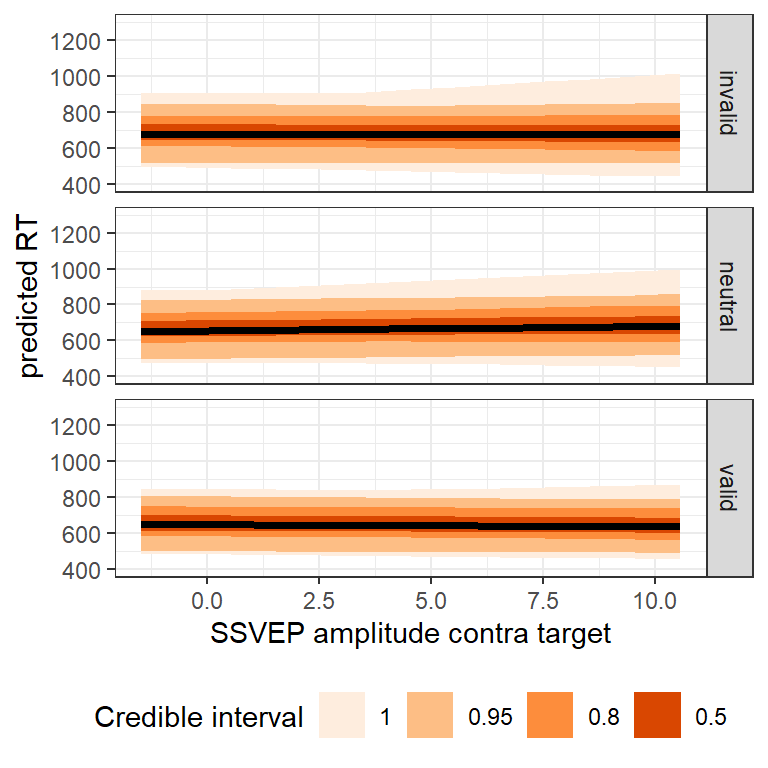

```r
theme_set(theme_bw())
g <- ggplot(bestmodel.ef.tidy_exppred2, aes(x = post_cue_SSVEP_contra_target, y = .epred)) +
  stat_lineribbon(.width = c(0.5, 0.8, 0.95, 1)) +
  scale_fill_brewer(palette = "Oranges") +
  # scale_fill_manual(values=c("red3")) +
  facet_grid(cue_validity_label~.)+
  labs(x = "SSVEP amplitude contra target", y = "predicted RT",
       fill = "Credible interval") +
  ylim(c(400,1300))+
  theme(legend.position = "bottom")

print(g)
```

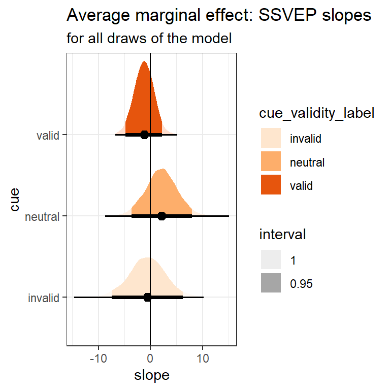

```r
# ggsave(filename = "figures/MarginEffects_PreTarget_FullModelSSVEP_SSVEP_Slopes.eps",
#        width = 3, height = 4,
#        plot = print(g))

# now lets get the slop of the modulation by alpha
bestmodel.ef.slope_contraTarget <- bestmodel.ef.model %>%
  emtrends(~ cue_validity_label, # 1 means, we want the average slop
           var = "post_cue_SSVEP_contra_target",
           epred = TRUE) %>%
  gather_emmeans_draws()



theme_set(theme_bw())
g <- ggplot(bestmodel.ef.slope_contraTarget, aes( x = .value, y=cue_validity_label)) +
  stat_halfeye(
    aes( fill = cue_validity_label, fill_ramp = after_stat(level)),
    .width = c(.95, 1),
  ) +
  # stat_dots(aes(fill = alpha_signal,color = alpha_signal, fill_ramp = after_stat(level), colour_ramp = after_stat(level)),
  #           .width = c(.95, 1))+
  geom_vline(xintercept = 0)+
  # scale_fill_manual(values=c("red3")) +
  scale_color_brewer(palette = "Oranges") +
  scale_fill_brewer(palette = "Oranges") +
  labs(
    title = "Average marginal effect: SSVEP slopes",
    subtitle = "for all draws of the model",
    fill_ramp = "interval",
    colour_ramp = "interval",
    x = "slope",
    y = "cue"
  )

print(g)
```

```r
# ggsave(filename = "figures/MarginEffects_PreTarget_FullModelSSVEP_SSVEP_SlopeDistr.eps",
#        width = 3, height = 4,
#        plot = print(g))

bestmodel.ef.slope_contraTarget %>% median_hdi() %>%
  kable(escape = F, digits = c(3,3,3,3,6,6,6,6,6), caption = c("SSVEP slope: mean and CI")) %>%
  kable_styling("striped", full_width = T, bootstrap_options = c("striped", "hover", "condensed", "responsive",font_size = 8))
```

SSVEP slope: mean and CI

| cue_validity_label | .value | .lower | .upper | .width | .point | .interval |
| --- | --- | --- | --- | --- | --- | --- |
| invalid | -0.563 | -7.673 | 5.863 | 0.95 | median | hdi |
| neutral | 2.137 | -3.718 | 7.821 | 0.95 | median | hdi |
| valid | -1.202 | -4.787 | 2.259 | 0.95 | median | hdi |

### Extract marginal effects for post-target motor alpha * Validity model

Now for illustrating the whole picture, lets plot the motor alpha model

**‘RT ~ Cue x motor_alpha_Targ + ( cue | subjects)’**

```r
# based on https://www.andrewheiss.com/blog/2021/11/10/ame-bayes-re-guide/
# which model to use?
bestmodel.ef.model <- fit_posttarg_validity_x_motoralpha
# what is the data of the model?
bestmodel.ef.data <- bestmodel.ef.model$data

# see data
#head(bestmodel.ef.data)

# show effects of the model
tidy(bestmodel.ef.model)%>%
  kable(escape = F, digits = c(6,6,6,6,6,6,6,6,6), caption = c("effects of best model")) %>%
  kable_styling("striped", full_width = T, bootstrap_options = c("striped", "hover", "condensed", "responsive",font_size = 8))
```

effects of best model

| effect | component | group | term | estimate | std.error | conf.low | conf.high |
| --- | --- | --- | --- | --- | --- | --- | --- |
| fixed | cond | NA | (Intercept) | 6.206552 | 0.034145 | 6.140429 | 6.272331 |
| fixed | cond | NA | cue_validity_labelneutral | -0.041724 | 0.009220 | -0.059628 | -0.023276 |
| fixed | cond | NA | cue_validity_labelvalid | -0.061313 | 0.009391 | -0.079280 | -0.042469 |
| fixed | cond | NA | post_target_malpha_contra_target | 0.016178 | 0.005998 | 0.004241 | 0.027930 |
| fixed | cond | NA | cue_validity_labelneutral:post_target_malpha_contra_target | 0.007373 | 0.008121 | -0.008325 | 0.023065 |
| fixed | cond | NA | cue_validity_labelvalid:post_target_malpha_contra_target | 0.007023 | 0.006999 | -0.006352 | 0.021086 |
| ran_pars | cond | subject | sd__(Intercept) | 0.153346 | 0.023827 | 0.114338 | 0.207050 |
| ran_pars | cond | subject | sd__cue_validity_labelneutral | 0.016759 | 0.011065 | 0.000891 | 0.041955 |
| ran_pars | cond | subject | sd__cue_validity_labelvalid | 0.032939 | 0.010045 | 0.013817 | 0.053344 |
| ran_pars | cond | subject | cor__(Intercept).cue_validity_labelneutral | 0.199555 | 0.415702 | -0.670220 | 0.877007 |
| ran_pars | cond | subject | cor__(Intercept).cue_validity_labelvalid | -0.089445 | 0.277268 | -0.585521 | 0.491509 |
| ran_pars | cond | subject | cor__cue_validity_labelneutral.cue_validity_labelvalid | 0.362426 | 0.441142 | -0.691955 | 0.938896 |
| ran_pars | cond | Residual | sd__Observation | 0.261796 | 0.004678 | 0.252274 | 0.270692 |

We then create a new data set with an alpha amplitude value fixed at the median of the original data, to be able to illustrate the distribution of the marginal means and their effect for the attentional cue, i.e. the factor **validity**

Based on the new data we can extract **predicted values** or **expected predicted values**. The former also includes the uncertainty for each individual observation (e.g., observational-level residual variance) of each prediction. We’re however more interested in the latter, which more focusses on the uncertainty in the model parameters and not necessarily the individual-level residuals.

```r
# use range of data from orignal study
bestmodel.ef.newdata3 <- expand_grid(
  cue_validity_label = c('valid','neutral','invalid'),
  post_target_malpha_contra_target = median(bestmodel.ef.data$post_target_malpha_contra_target),
  # contra_nontarget = median(bestmodel.ef.data$contra_nontarget),
  # contra_target = seq(min(bestmodel.ef.data$contra_target),max(bestmodel.ef.data$contra_target),1),
  # contra_nontarget = seq(min(bestmodel.ef.data$contra_nontarget),max(bestmodel.ef.data$contra_nontarget),1),
  # subject = as.factor(unique(bestmodel.ef.data$subject))
  subject = as.factor(c(120)) # for a 'new' subject
)

# use 'predicted_draws' to draw from posterior predictive distribution
# this still incorporates variance of each individual observation in the model
# we may not want to have this around for marginal effects, awe we're more focused on the expected value
bestmodel.ef.tidy_pred <- bestmodel.ef.model %>%
  predicted_draws(newdata = bestmodel.ef.newdata3, allow_new_levels = TRUE)
head(bestmodel.ef.tidy_pred)%>%
  kable(escape = F, digits = c(6,6,6,6,6,6,6,6,6), caption = c("predicted data")) %>%
  kable_styling("striped", full_width = T, bootstrap_options = c("striped", "hover", "condensed", "responsive",font_size = 8))
```

predicted data

| cue_validity_label | post_target_malpha_contra_target | subject | .row | .chain | .iteration | .draw | .prediction |
| --- | --- | --- | --- | --- | --- | --- | --- |
| valid | -0.204762 | 120 | 1 | NA | NA | 1 | 602.92039 |
| valid | -0.204762 | 120 | 1 | NA | NA | 2 | 649.59392 |
| valid | -0.204762 | 120 | 1 | NA | NA | 3 | 858.92297 |
| valid | -0.204762 | 120 | 1 | NA | NA | 4 | 623.05368 |
| valid | -0.204762 | 120 | 1 | NA | NA | 5 | 867.58563 |
| valid | -0.204762 | 120 | 1 | NA | NA | 6 | 553.80477 |

```r
# use 'expected draws' ('epred_draws') as we're more intereste in the expected value of the outcome
# which means we’re more focused on the uncertainty in the model parameters and not necessarily the individual-level residuals
# same as fitte function (only with nicer wrapper)
bestmodel.ef.tidy_exppred <- bestmodel.ef.model %>%
  epred_draws(newdata = bestmodel.ef.newdata3, allow_new_levels = TRUE)
head(bestmodel.ef.tidy_exppred)%>%
  kable(escape = F, digits = c(6,6,6,6,6,6,6,6,6), caption = c("predicted data")) %>%
  kable_styling("striped", full_width = T, bootstrap_options = c("striped", "hover", "condensed", "responsive",font_size = 8))
```

predicted data

| cue_validity_label | post_target_malpha_contra_target | subject | .row | .chain | .iteration | .draw | .epred |
| --- | --- | --- | --- | --- | --- | --- | --- |
| valid | -0.204762 | 120 | 1 | NA | NA | 1 | 621.47498 |
| valid | -0.204762 | 120 | 1 | NA | NA | 2 | 645.74117 |
| valid | -0.204762 | 120 | 1 | NA | NA | 3 | 806.96427 |
| valid | -0.204762 | 120 | 1 | NA | NA | 4 | 561.13720 |
| valid | -0.204762 | 120 | 1 | NA | NA | 5 | 768.01935 |
| valid | -0.204762 | 120 | 1 | NA | NA | 6 | 648.19384 |

Now with the `emmeans` package, we can extract the distribution of median RTs derived from the predicted RT-value distributions of each single draw/simulation. We can also directly calculate contrasts and derive the 95%-CI of the effects.

```r
# now we want to see the effects using emmeans
# check cue validity effect via pairwise comparisons
# first the emmeans (point estimate = median of distrbution)
bestmodel.ef.model %>%
  emmeans(~ cue_validity_label,
          epred = TRUE)%>%
  kable(escape = F, digits = c(3,3,3,6,3,3,3,3,3),
        caption = c("average marginal effect | point measure = median of RT in ms")) %>%
  # kable_classic(full_width = F) %>%
  column_spec(1, bold = T)%>%
  kable_styling("striped", full_width = T, bootstrap_options = c("striped", "hover", "condensed", "responsive",font_size = 8))
```

average marginal effect | point measure = median of RT in ms

| cue_validity_label | emmean | lower.HPD | upper.HPD |
| --- | --- | --- | --- |
| invalid | 680.804 | 652.501 | 712.92138 |
| neutral | 659.975 | 631.159 | 690.08438 |
| valid | 650.570 | 622.244 | 678.50405 |

```r
# pairwise comparisons
bestmodel.ef.model %>%
  emmeans(~ cue_validity_label,
          epred = TRUE)%>%
  contrast(method = "revpairwise")%>%
  kable(escape = F, digits = c(3,3,3,6,3,3,3,3,3),
        caption = c("average marginal effect differences | point measure = median of RT in ms")) %>%
  # kable_classic(full_width = F) %>%
  column_spec(1, bold = T)%>%
  kable_styling("striped", full_width = T, bootstrap_options = c("striped", "hover", "condensed", "responsive",font_size = 8))
```

average marginal effect differences | point measure = median of RT in ms

| contrast | estimate | lower.HPD | upper.HPD |
| --- | --- | --- | --- |
| neutral - invalid | -21.039 | -29.555 | -11.476542 |
| valid - invalid | -30.591 | -40.145 | -21.403586 |
| valid - neutral | -9.567 | -18.447 | -0.971122 |

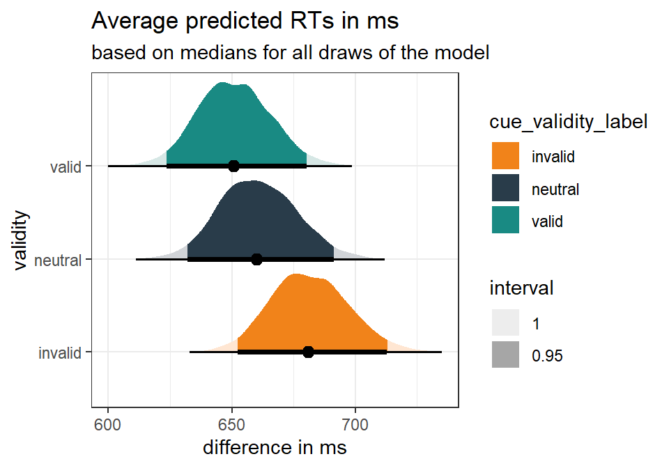

```r
# now gather all the single draws to be able to plot the variance predicted RTs for different validity levels
bestmodel.ef.ef_draws_validity <- bestmodel.ef.model %>%
  emmeans(~ cue_validity_label,
          epred = TRUE)%>%
  gather_emmeans_draws()

theme_set(theme_bw())
g <- ggplot(bestmodel.ef.ef_draws_validity, aes(y = cue_validity_label, x = .value)) +
  stat_halfeye(
    aes(fill = cue_validity_label, fill_ramp = after_stat(level)),
    .width = c(.95, 1),
    position = "dodgejust",
  ) +
  scale_fill_manual(values=c("#F1831A", "#293C4A", "#198A83")) +
  scale_color_manual(values=c("#F1831A", "#293C4A", "#198A83"))+
  labs(
    title = "Average predicted RTs in ms",
    subtitle = "based on medians for all draws of the model",
    fill_ramp = "interval",
    x = "difference in ms",
    y = "validity"
  )

print(g)
```

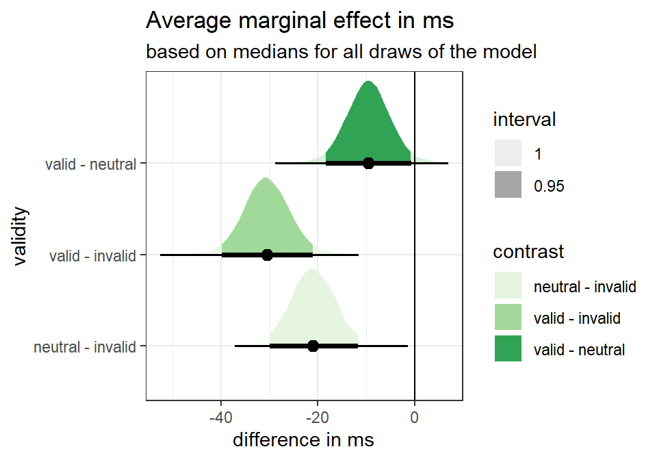

```r
# ggsave(filename = "figures/MarginEffects_PostTarget_FullModelMotAlpha_ValidityEffects.eps",
#        width = 5, height = 3.5,
#        plot = print(g))



# now gather all the single draws to be able to plot the variance of the contrast
bestmodel.ef.ef_draws_validity_contr <- bestmodel.ef.model %>%
  emmeans(~ cue_validity_label,
          epred = TRUE)%>%
  contrast(method = "revpairwise") %>%
  gather_emmeans_draws()

theme_set(theme_bw())
g <- ggplot(bestmodel.ef.ef_draws_validity_contr, aes(y = contrast, x = .value)) +
  stat_halfeye(
    aes(fill = contrast, fill_ramp = after_stat(level)),

    .width = c(.95, 1),
    position = "dodgejust",
  ) +
  geom_vline(xintercept = 0)+
  scale_fill_brewer(palette = "Greens")+
  labs(
    title = "Average marginal effect in ms",
    subtitle = "based on medians for all draws of the model",
    fill_ramp = "interval",
    x = "difference in ms",
    y = "validity"
  )

print(g)
```

```r
# ggsave(filename = "figures/MarginEffects_PostTarget_FullModelMotAlpha_ValidityEffectContrasts.eps",
#        width = 5, height = 3.5,
#        plot = print(g))
```

We now can similarly extract the slopes of the **alpha** and **RT** relationship

```r
# now trying to get the regression line right for the alpha predictors


## alpha contra target
# use range of data from orignal study with varying alpha contra target (in range of original data)
bestmodel.ef.newdata4 <- expand_grid(
  cue_validity_label = c('valid','neutral','invalid'),
  post_target_malpha_contra_target = seq(min(bestmodel.ef.data$post_target_malpha_contra_target),max(bestmodel.ef.data$post_target_malpha_contra_target),1),
  subject = as.factor(c(120)) # for a 'new' subject
)

# use 'expected draws' ('epred_draws') as we're more intereste in the expected value of the outcome
# which means we’re more focused on the uncertainty in the model parameters and not necessarily the individual-level residuals
# same as fitte function (only with nicer wrapper)
bestmodel.ef.tidy_exppred2 <- bestmodel.ef.model %>%
  epred_draws(newdata = bestmodel.ef.newdata4, allow_new_levels = TRUE)
head(bestmodel.ef.tidy_exppred2)%>%
  kable(escape = F, digits = c(6,6,6,6,6,6,6,6,6), caption = c("predicted data")) %>%
  kable_styling("striped", full_width = T, bootstrap_options = c("striped", "hover", "condensed", "responsive",font_size = 8))
```

predicted data

| cue_validity_label | post_target_malpha_contra_target | subject | .row | .chain | .iteration | .draw | .epred |
| --- | --- | --- | --- | --- | --- | --- | --- |
| valid | -1.642615 | 120 | 1 | NA | NA | 1 | 600.28251 |
| valid | -1.642615 | 120 | 1 | NA | NA | 2 | 621.92882 |
| valid | -1.642615 | 120 | 1 | NA | NA | 3 | 642.85368 |
| valid | -1.642615 | 120 | 1 | NA | NA | 4 | 681.10715 |
| valid | -1.642615 | 120 | 1 | NA | NA | 5 | 659.30579 |
| valid | -1.642615 | 120 | 1 | NA | NA | 6 | 656.43697 |

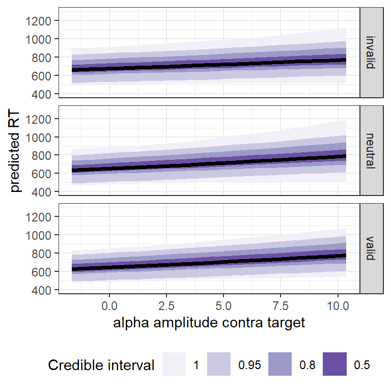

```r
theme_set(theme_bw())
g <- ggplot(bestmodel.ef.tidy_exppred2, aes(x = post_target_malpha_contra_target, y = .epred)) +
  stat_lineribbon(.width = c(0.5, 0.8, 0.95, 1)) +
  scale_fill_brewer(palette = "Purples") +
  facet_grid(cue_validity_label~.)+
  labs(x = "alpha amplitude contra target", y = "predicted RT",
       fill = "Credible interval") +
  ylim(c(400,1300))+
  theme(legend.position = "bottom")

# now lets get the slop of the modulation by alpha
bestmodel.ef.slope_contraTarget <- bestmodel.ef.model %>%
  emtrends(~ cue_validity_label, # 1 means, we want the average slop
           var = "post_target_malpha_contra_target",
           epred = TRUE) %>%
  gather_emmeans_draws()

print(g)
```

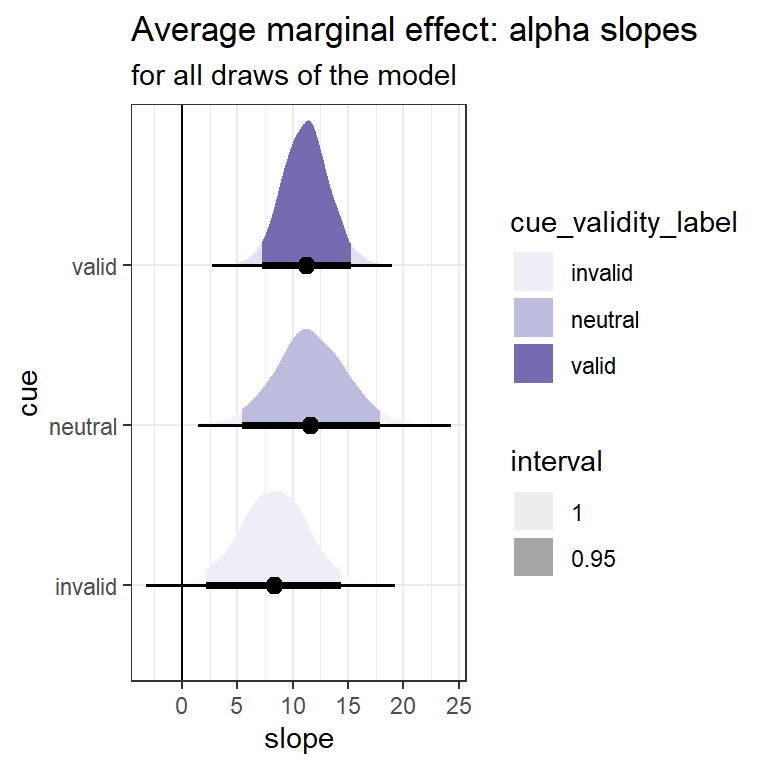

```r
# ggsave(filename = "figures/MarginEffects_PostTarget_FullModelMotAlpha_MotAlpha_Slopes.eps",
#        width = 4, height = 4,
#        plot = print(g))




theme_set(theme_bw())
g <- ggplot(bestmodel.ef.slope_contraTarget, aes( x = .value, y=cue_validity_label)) +
  stat_halfeye(
    aes( fill = cue_validity_label, fill_ramp = after_stat(level)),
    .width = c(.95, 1),
  ) +
  # stat_dots(aes(fill = alpha_signal,color = alpha_signal, fill_ramp = after_stat(level), colour_ramp = after_stat(level)),
  #           .width = c(.95, 1))+
  geom_vline(xintercept = 0)+
  # scale_fill_manual(values=c("red3")) +
  scale_color_brewer(palette = "Purples") +
  scale_fill_brewer(palette = "Purples") +
  labs(
    title = "Average marginal effect: alpha slopes",
    subtitle = "for all draws of the model",
    fill_ramp = "interval",
    colour_ramp = "interval",
    x = "slope",
    y = "cue"
  )
#
print(g)
```

```r
# ggsave(filename = "figures/MarginEffects_PostTarget_FullModelMotAlpha_MotAlpha_SlopeDistr.eps",
#        width = 4, height = 4,
#        plot = print(g))


bestmodel.ef.slope_contraTarget %>% median_hdi() %>%
  kable(escape = F, digits = c(3,3,3,3,6,6,6,6,6), caption = c("alpha slope: mean and CI")) %>%
  kable_styling("striped", full_width = T, bootstrap_options = c("striped", "hover", "condensed", "responsive",font_size = 8))
```

alpha slope: mean and CI

| cue_validity_label | .value | .lower | .upper | .width | .point | .interval |
| --- | --- | --- | --- | --- | --- | --- |
| invalid | 8.348 | 2.031 | 14.117 | 0.95 | median | hdi |
| neutral | 11.540 | 5.311 | 17.748 | 0.95 | median | hdi |
| valid | 11.216 | 7.226 | 15.250 | 0.95 | median | hdi |